# Seminar 9: Text-as-Data Methods in Political Science

Author

Zach Dickson

# Start here:

This notebook provides an example of how to use text-as-data methods in R. There are three example datasets provided in the data folder: Reddit posts on climate change (`reddit_climate_change_2022_sample.csv`), Parliament oral questions from PMQs (`commons_oral_questions.csv`), and UK Green Party Press Releases (`uk_green_party_press_releases.csv`). There are two different methods demonstrated in this notebook: dictionary-based methods and sentiment analysis. You can choose one or both methods to apply to your data.

- **Step 1:**
  - Choose a dataset to analyze. You can use one of the provided datasets or bring your own text data.
- **Step 2:**
  - Choose a method to apply to the data: dictionary-based methods or sentiment analysis.
- **Step 3:**
  - Apply the chosen method to the data and analyze the results.

```r
# install packages if they are not already installed

# List of package names to install
packages_to_install <- c('tidyverse', 'sentimentr', 'wordcloud2')

# Check if each package is already installed
for (package_name in packages_to_install) {
  if (!(package_name %in% installed.packages())) {
    # If not installed, install the package
    install.packages(package_name)
  }
}


# load libraries
library(tidyverse)
library(sentimentr)
library(wordcloud2)
# set the working directory to the location of this script
# setwd("../this_script_directory")
```

#### Load the desired data file

1. Reddit Data: `reddit_climate_change_2022_sample.csv`
2. Parliament Data: `commons_oral_questions.csv`
3. Party Press Releases: `uk_green_party_press_releases.csv`

```r
# Load the data
data <- read_csv("data/commons_oral_questions.csv")
# Explore the data columns and structure
colnames(data)
```

```
 [1] "uri"
 [2] "date"
 [3] "answer_date_time"
 [4] "answering_body"
 [5] "commons_question_time_>_question_type"
 [6] "location_>_pref_label"
 [7] "question_status"
 [8] "ballot_number"
 [9] "date_tabled"
[10] "modified"
[11] "text"
[12] "tabling_member_>_label"
[13] "tabling_member_>_uri"
[14] "tabling_member_>_constituency_>_pref_label"
[15] "tabling_member_printed"
[16] "uin"
[17] "tabling_member"
```

```r
# View the first few rows of the data
head(data)
```

```
# A tibble: 6 × 17
  uri       date       answer_date_time    answering_body commons_question_tim…¹
  <chr>     <date>     <dttm>              <chr>          <chr>
1 http://d… 2024-12-19 2024-12-19 00:00:00 Attorney Gene… Substantive
2 http://d… 2024-03-21 2024-03-21 00:00:00 Department fo… Substantive
3 http://d… 2024-11-20 2024-11-20 00:00:00 Department fo… Substantive
4 http://d… 2024-10-16 2024-10-16 00:00:00 Prime Minister Substantive
5 http://d… 2024-10-17 2024-10-17 00:00:00 Department fo… Topical
6 http://d… 2024-12-02 2024-12-02 00:00:00 Ministry of H… Substantive
# ℹ abbreviated name: ¹`commons_question_time_>_question_type`
# ℹ 12 more variables: `location_>_pref_label` <chr>, question_status <chr>,
#   ballot_number <dbl>, date_tabled <date>, modified <dttm>, text <chr>,
#   `tabling_member_>_label` <chr>, `tabling_member_>_uri` <chr>,
#   `tabling_member_>_constituency_>_pref_label` <chr>,
#   tabling_member_printed <chr>, uin <dbl>, tabling_member <chr>
```

```r
# print first 20 rows of the text column
data$text[1:20]
```

```
 [1] "What recent discussions she has had with Cabinet colleagues on prosecuting knife offences."
 [2] "What funding his Department is providing for road resurfacing."
 [3] "If he will take steps to support the creation of a global network of scientific research on frontier AI safety."
 [4] "If he will list his official engagements for Wednesday 16 October."
 [5] "If she will make a statement on her departmental responsibilities."
 [6] "What steps her Department is taking to support councils in reducing homelessness."
 [7] "If he will make a statement on his departmental responsibilities."
 [8] "If he will make a statement on his departmental responsibilities."
 [9] "What recent assessment she has made of the contribution of tourism to the local economies of coastal towns."
[10] "What steps his Department is taking to strengthen coastal defences."
[11] "If she will make a statement on her departmental responsibilities."
[12] "What assessment his Department has made of trends in the diversity of appointments to the House of Lords."
[13] "What steps she plans to take to help regenerate high streets."
[14] "What steps he is taking to improve the defence relationship with European allies."
[15] "What assessment he has made of the adequacy of access to NHS mental health services."
[16] "If he will list his official engagements for Wednesday 20 November."
[17] "If he will list his official engagements for Wednesday 1 May."
[18] "Whether he has had discussions with NHS England on including vasa praevia screening as part of antenatal care."
[19] "What steps she is taking to increase nuclear energy capacity."
[20] "If he will make a statement on his departmental responsibilities."
```

#### Make a word cloud of the text column

```r
# convert all text to one big string
text <- paste(data$text, collapse = " ")
# create a word frequency table
word_freq <- table(strsplit(text, "\\W+"))
# remove some stop words (we could add more to to this list)
stop_words <- c('and', 'a', 'the','I','for','in','it','is', 'on','this', 'be','at','just','or','do','if','how','https','like')
word_freq <- word_freq[!(names(word_freq) %in% stop_words)]
# convert the word frequency table to a data frame
word_freq_df <- as.data.frame(word_freq)
# print the wordcloud using the wordcloud2 package
wordcloud2(word_freq_df, size = 2, backgroundColor = "white")
```

[interactive chart not shown]

# Text analysis: Dictionary-based method

First, we need to create a dictionary for the analysis by making a list of words that indicate a topic of interest

```r
# Example: Climate Change Dictionary
climate_change_dictionary <- c('climate', 'environment', 'global warming', 'greenhouse gas', 'carbon', 'emission', 'pollution', 'fossil fuel', 'renewable', 'sustainability', 'ecosystem', 'biodiversity', 'deforestation', 'ocean acidification', 'sea level rise', 'extreme weather', 'heatwave', 'drought', 'flood', 'hurricane')


# create a function to count the number of times the words in the dictionary appear in a given text
count_dictionary_words <- function(text, dictionary) {
  # Convert the text to lowercase
  text <- tolower(text)
  # Split the text into words
  words <- strsplit(text, "\\W+")
  # Count the number of words in the dictionary that appear in the text for each row of the data
  count <- sum(sapply(words, function(word) sum(word %in% dictionary)))
  return(count)
}


# Apply the function to the text column of the data
data$climate_change_count <- sapply(data$text, count_dictionary_words, dictionary = climate_change_dictionary)

# print the value counts of the climate_change_count column
table(data$climate_change_count)
```

```
  0   1
494   6
```

#### Plot the number of climate change related words over time

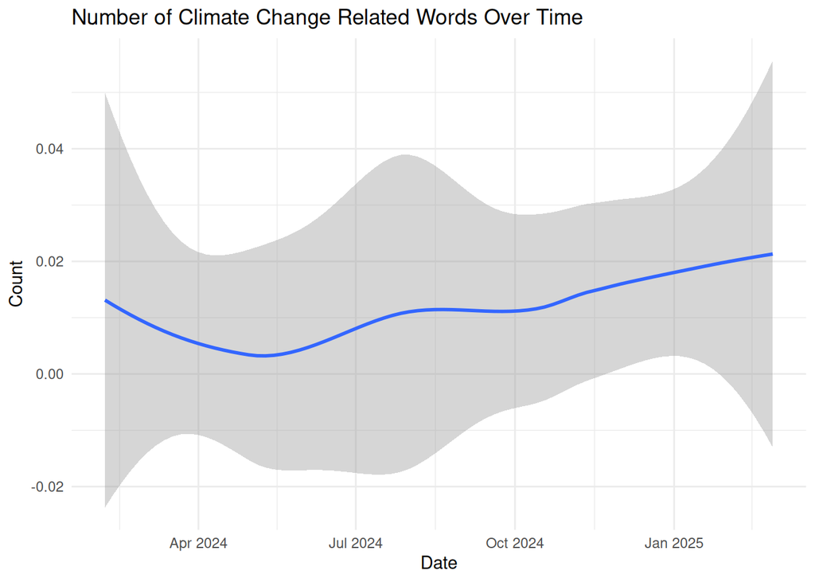

```r
data %>%
  ggplot(aes(x = date, y = climate_change_count)) +
   geom_smooth() + # we could swith to geom_point() to see the actual data points or geom_line() to see the line connecting the points
  labs(title = "Number of Climate Change Related Words Over Time",
       x = "Date",
       y = "Count") +
  theme_minimal()
```

# Sentiment Analysis

We’ll use the Sentimentr package to analyze the sentiment of the text data. Additional details about the library can be found here: https://github.com/trinker/sentimentr.

```r
# use the sentimentr package to calculate the sentiment of the text
sentiment <- sentiment_by(data$text)

# print the first few rows of the sentiment data
head(sentiment)
```

```
Key: <element_id>
   element_id word_count    sd ave_sentiment
        <int>      <int> <num>         <num>
1:          1         13    NA    -0.1109400
2:          2          9    NA     0.2666667
3:          3         20    NA     0.4695743
4:          4         10    NA     0.0000000
5:          5         10    NA     0.0000000
6:          6         12    NA     0.1443376
```

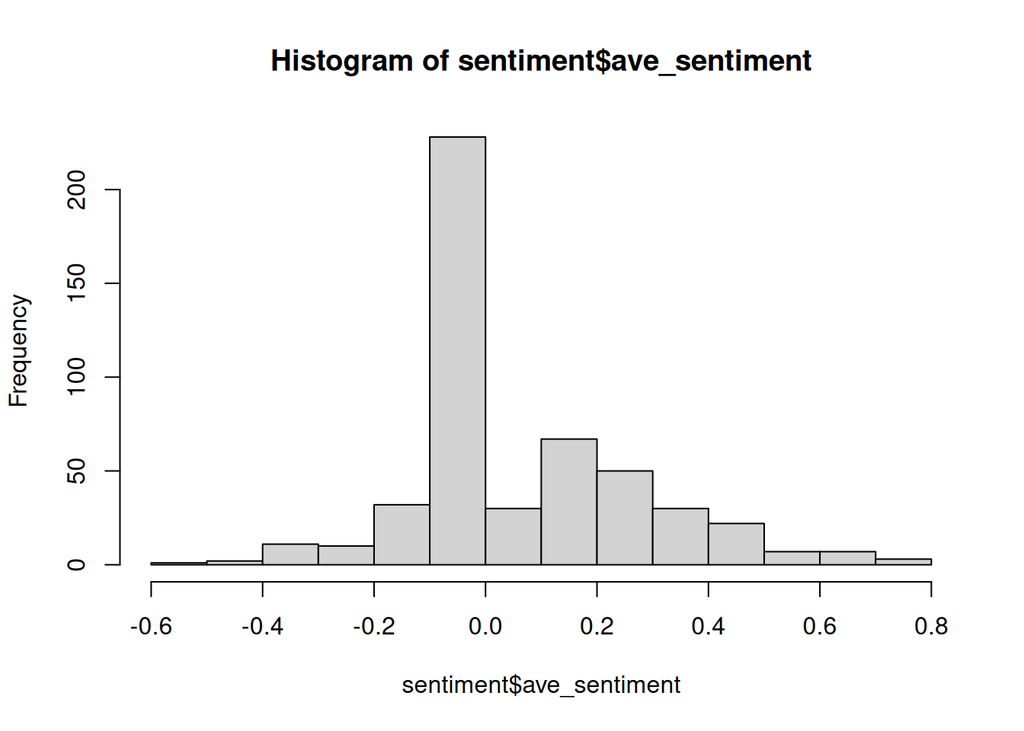

```r
# plot a histogram of the sentiment scores
hist(sentiment$ave_sentiment)
```

```r
# add the sentiment scores to the dataset
data$sentiment <- sentiment$ave_sentiment

# add the word count to the dataset
data$word_count <- sentiment$word_count
```

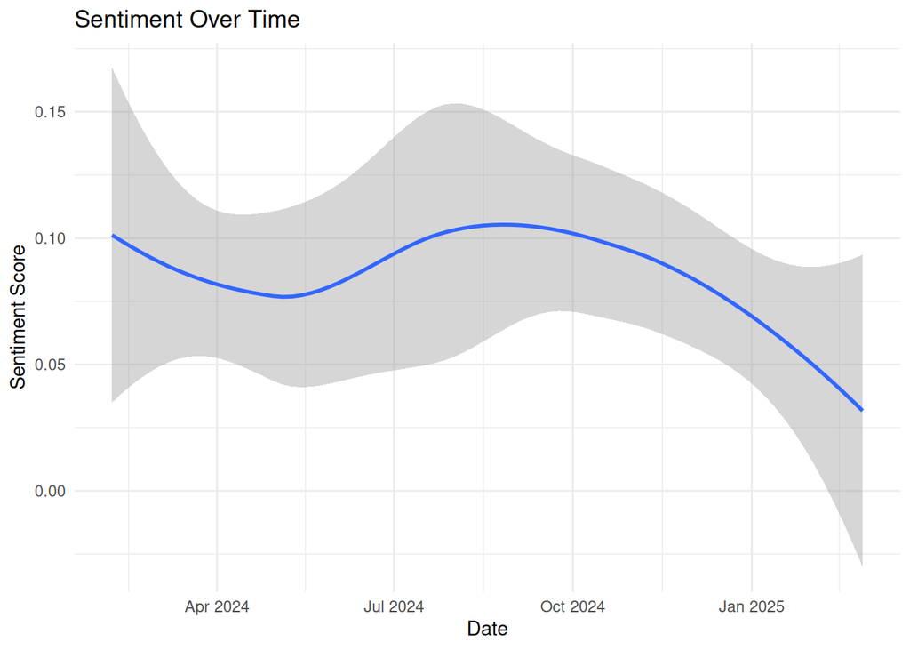

```r
# plot the sentiment over time using GGplot
data %>%
  ggplot(aes(x = date, y = sentiment)) +
  geom_smooth() +
  labs(title = "Sentiment Over Time",
       x = "Date",
       y = "Sentiment Score") +
  theme_minimal()
```